# Practical Machine Learning - Prediction Assignment Writeup

Lucia Martinez

28/5/2018

## Executive Summary

In this course project we attempt to build a machine learning model capable of predicting which of 5 possible ways a person was performing a dumbell curl exercise using the data took of devices such as Jawbone Up, Nike FuelBand, and Fitbit. Once the best model based on the accuracy measurement is selected, its performance is confirmed using a validation set. The conclusion is a random forest was able to generate better predictions with 99.64% of accuracy.

## Libraries

```r
library(caret)
library(randomForest)
library(corrplot)
library(ggplot2)
set.seed(12345)
```

## Data Loading, Cleaning & Exploratory Analysis

First, we load the datasets and the training dataset is partinioned in 2 to create a training set for the modeling process and a test set for the predicting process. The original testing dataset (from now on validation set in order to prevent confusion) is not changed and will only be used for the quiz results generation.

```r
urlTraining <-"https://d396qusza40orc.cloudfront.net/predmachlearn/pml-training.csv"
urlValidation <-"https://d396qusza40orc.cloudfront.net/predmachlearn/pml-testing.csv"
Training <- read.csv(url(urlTraining))
Validation  <- read.csv(url(urlValidation))
inTrain  <- createDataPartition(Training$classe, p=0.7, list=FALSE)
TrainingSet <- Training[inTrain, ]
TestSet  <- Training[-inTrain, ]
dim(TrainingSet)
```

```
## [1] 13737   160
```

```r
dim(TestSet)
```

```
## [1] 5885  160
```

Now, in the cleasing process we went to remove that variables with NA. Also, the Near Zero variance (NZV) variables are also removed and the ID variables as well.

```r
remNA <- sapply(TrainingSet, function(x) mean(is.na(x))) > 0.95
TrainingSet <- TrainingSet[, remNA==FALSE]
TestSet  <- TestSet[, remNA==FALSE]
NZV <- nearZeroVar(TrainingSet)
TrainingSet <- TrainingSet[, -NZV]
TestSet  <- TestSet[, -NZV]
TrainingSet <- TrainingSet[, -(1:5)]
TestSet  <- TestSet[, -(1:5)]
dim(TrainingSet)
```

```
## [1] 13737    54
```

```r
dim(TestSet)
```

```
## [1] 5885   54
```

Finally, in this step we analysed the correlation among variables. The highly correlated variables are shown in dark colors in the graph below. (For visual understanding, only 20 variables will be plotted.)

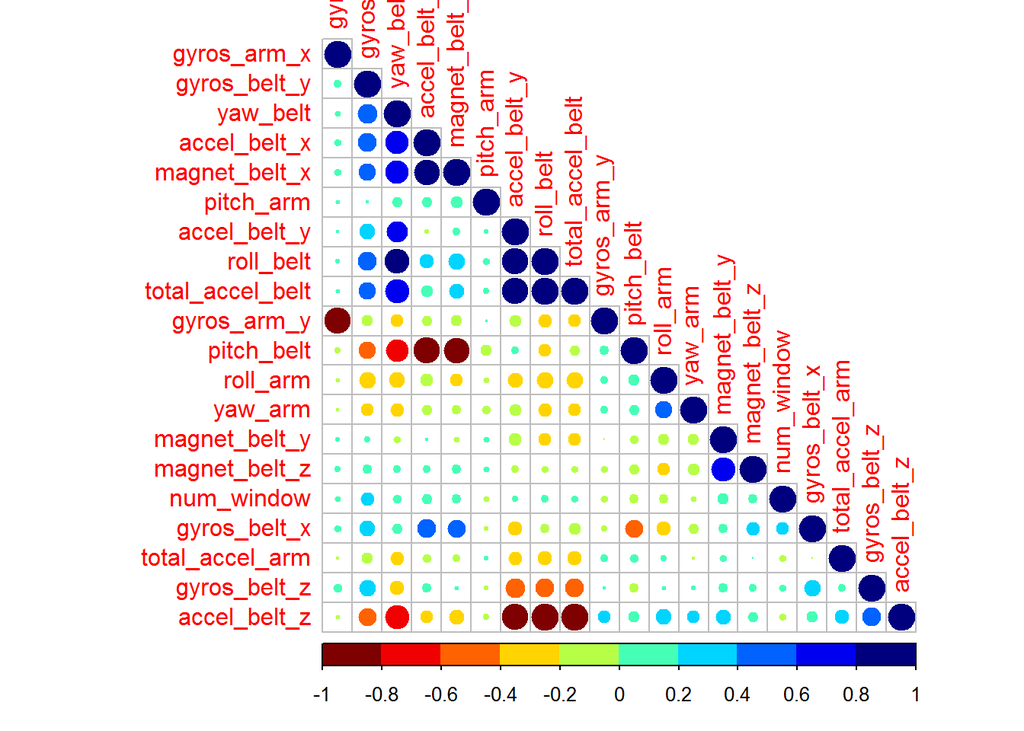

```r
corvar <- cor(TrainingSet[,-54])
col4 <- colorRampPalette(c("#7F0000", "red", "#FF7F00", "yellow", "#7FFF7F",
                           "cyan", "#007FFF", "blue", "#00007F"))
corrplot(corvar[1:20,1:20], type = "lower" ,order = "hclust", col= col4(10))
```

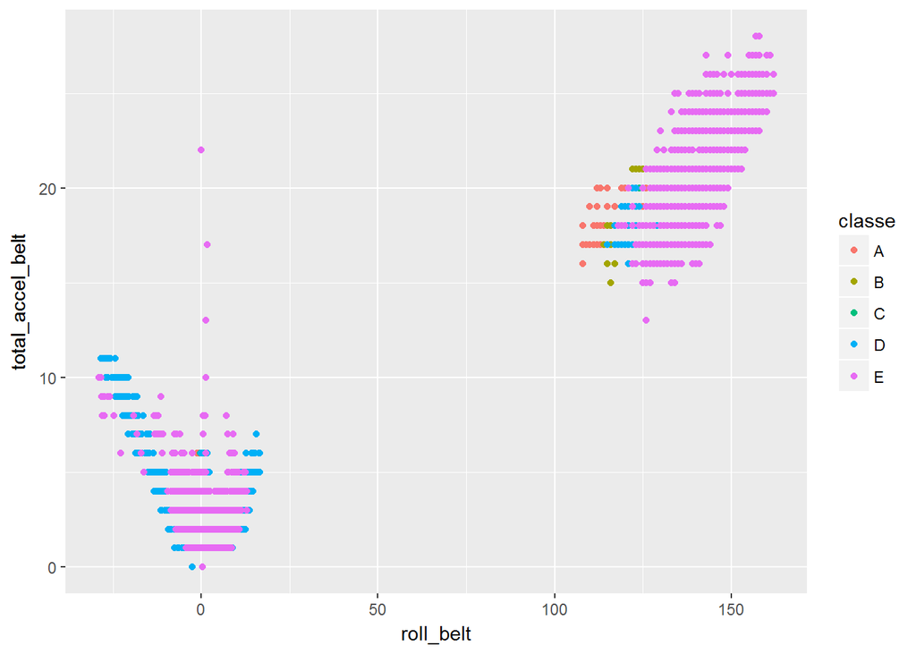

```r
qplot(roll_belt, total_accel_belt, data=TrainingSet, color=classe)
```

Both graph suggests that it is a good idea to use methods like Random Forest.

## Prediction and Modelling

We used two methods will be applied to model the regressions: Random Forests and Decision Tree, because as result of the exploratory analysis seems the methods that can work well. Only, the method with higher accuracy (via Confusion Matrix visualizes the accuracy of the models) will be used for the quiz predictions.

#### a. Random Forest

The accuracy of the model is **99.64%** and the estimated out-of-sample error is **0.36%**

```r
controlRF <- trainControl(method="cv", 3)
fitRF <- train(classe ~ ., data= TrainingSet, method="rf", trControl=controlRF)
fitRF
```

```
## Random Forest
##
## 13737 samples
##    53 predictor
##     5 classes: 'A', 'B', 'C', 'D', 'E'
##
## No pre-processing
## Resampling: Cross-Validated (3 fold)
## Summary of sample sizes: 9157, 9160, 9157
## Resampling results across tuning parameters:
##
##   mtry  Accuracy   Kappa
##    2    0.9931571  0.9913438
##   27    0.9960690  0.9950274
##   53    0.9937393  0.9920805
##
## Accuracy was used to select the optimal model using the largest value.
## The final value used for the model was mtry = 27.
```

```r
predictRF <- predict(fitRF, newdata=TestSet)
confusionMatrix(TestSet$classe, predictRF)
```

```
## Confusion Matrix and Statistics
##
##           Reference
## Prediction    A    B    C    D    E
##          A 1674    0    0    0    0
##          B    5 1133    1    0    0
##          C    0    2 1024    0    0
##          D    0    0    9  955    0
##          E    0    0    0    4 1078
##
## Overall Statistics
##
##                Accuracy : 0.9964
##                  95% CI : (0.9946, 0.9978)
##     No Information Rate : 0.2853
##     P-Value [Acc > NIR] : < 2.2e-16
##
##                   Kappa : 0.9955
##  Mcnemar's Test P-Value : NA
##
## Statistics by Class:
##
##                      Class: A Class: B Class: C Class: D Class: E
## Sensitivity            0.9970   0.9982   0.9903   0.9958   1.0000
## Specificity            1.0000   0.9987   0.9996   0.9982   0.9992
## Pos Pred Value         1.0000   0.9947   0.9981   0.9907   0.9963
## Neg Pred Value         0.9988   0.9996   0.9979   0.9992   1.0000
## Prevalence             0.2853   0.1929   0.1757   0.1630   0.1832
## Detection Rate         0.2845   0.1925   0.1740   0.1623   0.1832
## Detection Prevalence   0.2845   0.1935   0.1743   0.1638   0.1839
## Balanced Accuracy      0.9985   0.9985   0.9950   0.9970   0.9996
```

#### b. Decision Tree

The accuracy of the model is **52.37%** which is pretty bad! Note that the decision tree never predict a D classe.

```r
fitDT <- train(classe ~ ., data=TrainingSet, method="rpart", trControl=controlRF)
predictDT <- predict(fitDT, newdata=TestSet)
confusionMatrix(TestSet$classe,predictDT)
```

```
## Confusion Matrix and Statistics
##
##           Reference
## Prediction    A    B    C    D    E
##          A 1494   21  128    0   31
##          B  470  380  289    0    0
##          C  467   29  530    0    0
##          D  416  184  324    0   40
##          E   95   90  219    0  678
##
## Overall Statistics
##
##                Accuracy : 0.5237
##                  95% CI : (0.5109, 0.5365)
##     No Information Rate : 0.4999
##     P-Value [Acc > NIR] : 0.0001376
##
##                   Kappa : 0.3791
##  Mcnemar's Test P-Value : < 2.2e-16
##
## Statistics by Class:
##
##                      Class: A Class: B Class: C Class: D Class: E
## Sensitivity            0.5078  0.53977  0.35570       NA   0.9052
## Specificity            0.9388  0.85350  0.88714   0.8362   0.9213
## Pos Pred Value         0.8925  0.33363  0.51657       NA   0.6266
## Neg Pred Value         0.6561  0.93173  0.80243       NA   0.9852
## Prevalence             0.4999  0.11963  0.25319   0.0000   0.1273
## Detection Rate         0.2539  0.06457  0.09006   0.0000   0.1152
## Detection Prevalence   0.2845  0.19354  0.17434   0.1638   0.1839
## Balanced Accuracy      0.7233  0.69664  0.62142       NA   0.9133
```

## Conclusion & Predicting Results on the Test Data

The random forest is well suited to generating accurate predictions for this dataset. While a decision tree wasn’t able to accurately predict the response.

The Random Forest model will be applied to predict the 20 quiz results (validation dataset) as shown below.

```r
validationTest <- predict(fitRF, newdata=Validation)
validationTest
```

```
##  [1] B A B A A E D B A A B C B A E E A B B B
## Levels: A B C D E
```